# Session 02 - Social Network Analysis

Network representations and basic manipulations in R

Published

3/14/25

Welcome to the second session of the seminar **Computational Social Sciences**

# Social networks

A **social network** consists of a set of **actors** that are connected by **relationships** in a pairwise manner (Wasserman and Faust 2009). Actors can represent individuals, groups, organizations, companies, or even entire countries. The nature of these relationships varies and can be defined in different ways, such as:

- **Similarity-based relationships** (e.g., shared interests, attributes, or behaviors)
- **Role- and position-based relationships** (e.g., hierarchies, affiliations, or professional connections)
- **Resource-transfer relationships** (e.g., exchange of information, goods, or support)

Networks are commonly visualised in plots by **nodes** (usually circles), representing the actors and **edges** (lines or arrows) , representing the relationships.

```r
library(igraph)
library(ggraph)
library(ggplot2)

# Set seed for reproducibility
set.seed(123)

# Generate a random graph with 30 nodes and 50 edges
g <- erdos.renyi.game(n = 60, p.or.m = 70, type = "gnm", directed = FALSE)

# Assign random colors to nodes
V(g)$color <- sample(c("blue", "green"), vcount(g), replace = TRUE)

# Assign random sizes to nodes
V(g)$size <- sample(5:12, vcount(g), replace = TRUE)

  # Plot the network using ggraph
p1 <-ggraph(g, layout = "fr") +
      geom_edge_link(color = "lightgray", alpha = 0.5) +
      geom_node_point(aes(size = size, color = color), alpha = 0.8) +
      scale_color_manual(values = c("blue" = "#967bb6", "green" = "#e8bff7")) +
      theme_void() +
      theme(legend.position = "none")
```

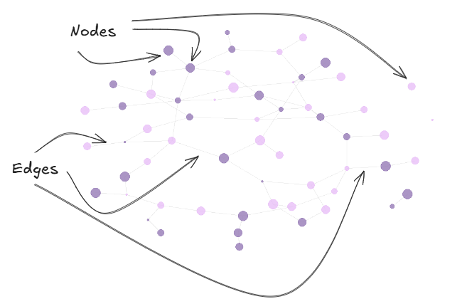

Social network with nodes and edges

## Social Network Analysis

(Content from Omar Lizardo)

When we speak about social network analysis from a sociological view, there are two broad aspects, that we most commonly talk about.

For one we talk about concepts that we refer to as *network theories*, meaning theories and ideas about how people behave in social embeddings and how networks themselves “behave”. Questions, that are central to this are, where do network relations come from, how are they formed, what consequences do they have for the people involved?

#### Excercise

Reflect briefly on the occasions, where in the past you have been confronted with social networks theories. In what theoretical concepts of sociology is the embedding of actors of central importance?

The other big branch focuses mostly on the description of networks and on how to measure various network properties. It links social network contexts to a quantitative representation.

In this class we will try to have a look at both “Faces” of social network analysis. We will learn some of the basic concepts and how they connect to measurable network properties.

## Types of social networks

In social network analysis, we distinguish between **directed** and **undirected** networks. In most real-world cases, **directed networks** are more realistic because relationships are often asymmetric. However, **undirected networks** are easier to analyze mathematically and computationally.

### Directed Networks

Directed networks represent relationships where the connection has a defined direction. These relationships do not necessarily have to be reciprocal.

$$\forall A,B \in V:(A \to B) \not\Rightarrow (B \to A)$$

**Examples:**  
- **Social media interactions**: On Twitter or Instagram, one user can follow another without being followed back.  
- **Communication networks**: E-Mails, phone calls or other forms of communication, can be sent out or received, thus defining a direction.

### Undirected Networks

Undirected networks assume that if a connection exists, it is inherently mutual. These networks are simpler to analyze since they do not require considering directionality.

$$\forall A, B \in V: (A \leftrightarrow B) \Rightarrow (B \leftrightarrow A)$$

**Examples:**  
- **Mutual friendships**: In many studies, friendship networks are assumed to be undirected, meaning if A considers B a friend, B also considers A a friend (although this is not always the case in reality).  
- **Co-authorship networks**: If two researchers have co-authored a paper together, the connection exists for both equally.  
- **Collaboration networks**: In corporate or scientific collaborations, individuals or institutions work together on projects, making the relationship inherently bidirectional. - **Classmates**

In practice, the choice between directed and undirected networks depends on the research question. If directionality is crucial (e.g., influence, hierarchy, or information flow), a **directed network** is necessary. However, if the goal is to analyze overall connectivity, **undirected networks** provide a simpler approach.

```r
library(patchwork)  # For arranging plots


# Generate a random graph with 30 nodes and 50 edges
g2 <- erdos.renyi.game(n = 60, p.or.m = 70, type = "gnm", directed = TRUE)

# Assign random colors to nodes
V(g2)$color <- sample(c("blue", "green"), vcount(g2), replace = TRUE)

# Assign random sizes to nodes
V(g2)$size <- sample(5:12, vcount(g2), replace = TRUE)

  # Plot the network using ggraph
p1 <- ggraph(g, layout = "fr") +
      geom_edge_link(color = "lightgray", alpha = 0.5) +
      geom_node_point(aes(size = size, color = color), alpha = 0.8) +
      scale_color_manual(values = c("blue" = "#967bb6", "green" = "#e8bff7")) +
      theme_void() +
      theme(legend.position = "none") +
      ggtitle("Undirected Network")

# Create the directed network plot
p2 <- ggraph(g2, layout = "fr") +
  geom_edge_link(arrow = arrow(length = unit(1.5, "mm"), type = "closed"), color = "lightgray", alpha = 0.5) +
  geom_node_point(aes(size = size, color = color), alpha = 0.8) +
  scale_color_manual(values = c("blue" = "#967bb6", "green" = "#e8bff7")) +
  theme_void() +
  theme(legend.position = "none") +
  ggtitle("Directed Network")

# Arrange the two plots side by side
p1 + p2
```

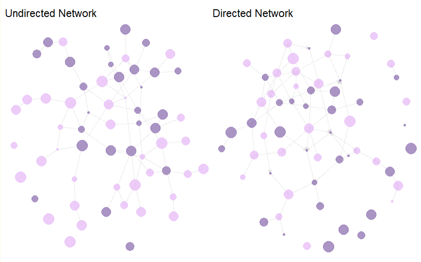

# Social network analysis (SNA) in R

## From ties to graphs

Imagine you where to plot all relationships of all people in the world. Of course, this is just not possible, as the measurement but also the representation would be too complex. Thus we need some kind of (theoretical) bounds, that make the analysis of networks possible.

In social network analysis, we use **graphs** to represent social networks. We borrow graphs from the mathematical **graph theory** which also provides us with a definition.

A graph is a set $G$ and thus a collection of entities.

In the case of graphs, the entities inside the set are a set of vertices and a seperate set of edges.

$$G = \{V, E\}$$

## Network representations

### Adjacency matrices

In graph theory and computer science an adjacencyy matric is a matrix used to represent a finite graph. The elements of a matrix indicate whether pairs of vertices are adjacent (or not) in the graph.

## References

Wasserman, Stanley, and Katherine Faust. 2009. *Social Network Analysis: Methods and Applications*. 18. print. Structural Analysis in the Social Sciences 8. Cambridge: Cambridge Univ. Press.

## Copyright

Copyright Leonie Steinbrinker, 2024. All Rights Reserved